# dataanalysis

```python
import pandas as pd

# 엑셀 파일 이름 설정 (주피터 노트북과 같은 경로에 있을 경우)
file_name = 'AI_MBA_DataAnalysis_Example.xlsx'

# ExcelFile 객체를 생성하여 파일의 메타데이터를 읽습니다.
excel_file = pd.ExcelFile(file_name)

# 시트 이름 목록을 출력합니다.
print("엑셀 파일 내 시트 목록:", excel_file.sheet_names)
```

```
엑셀 파일 내 시트 목록: ['README', 'Sales_POS', 'CRM_Customers', 'CRM_Orders', 'HR_Employees', 'Text_Reviews']
```

```python
import pandas as pd

# 1. 데이터 로드
file_name = 'AI_MBA_DataAnalysis_Example.xlsx'
df_customers = pd.read_excel(file_name, sheet_name='CRM_Customers')
df_orders = pd.read_excel(file_name, sheet_name='CRM_Orders')

# 2. 'CRM_Customers' 시트 상황 확인
print("-" * 30)
print("[1] CRM_Customers 시트 정보")
print("-" * 30)
print(f"데이터 크기: {df_customers.shape}") # (행, 열) 개수
print("\n<컬럼 구성 및 데이터 타입>")
print(df_customers.info()) # 컬럼명, 데이터 타입, 결측치 확인
print("\n<통계적 요약>")
display(df_customers.describe(include='all').T) # 수치형/범주형 데이터 요약
print("\n<데이터 상위 5행>")
display(df_customers.head())

# 3. 'CRM_Orders' 시트 상황 확인
print("\n" + "=" * 50 + "\n")
print("-" * 30)
print("[2] CRM_Orders 시트 정보")
print("-" * 30)
print(f"데이터 크기: {df_orders.shape}")
print("\n<컬럼 구성 및 데이터 타입>")
print(df_orders.info())
print("\n<통계적 요약>")
display(df_orders.describe(include='all').T)
print("\n<데이터 상위 5행>")
display(df_orders.head())
```

```
------------------------------
[1] CRM_Customers 시트 정보
------------------------------
데이터 크기: (350, 10)

<컬럼 구성 및 데이터 타입>
<class 'pandas.core.frame.DataFrame'>
RangeIndex: 350 entries, 0 to 349
Data columns (total 10 columns):
 #   Column                    Non-Null Count  Dtype
---  ------                    --------------  -----
 0   customer_id               350 non-null    object
 1   customer_name             350 non-null    object
 2   gender                    350 non-null    object
 3   birth_date                350 non-null    datetime64[ns]
 4   age                       350 non-null    int64
 5   region                    350 non-null    object
 6   join_date                 350 non-null    datetime64[ns]
 7   membership_grade          350 non-null    object
 8   email_opt_in              350 non-null    object
 9   preferred_contact_method  350 non-null    object
dtypes: datetime64[ns](2), int64(1), object(7)
memory usage: 27.5+ KB
None

<통계적 요약>
```

|  | count | unique | top | freq | mean | min | 25% | 50% | 75% | max | std |
| --- | --- | --- | --- | --- | --- | --- | --- | --- | --- | --- | --- |
| customer_id | 350 | 350 | C202400350 | 1 | NaN | NaN | NaN | NaN | NaN | NaN | NaN |
| customer_name | 350 | 350 | 고객350 | 1 | NaN | NaN | NaN | NaN | NaN | NaN | NaN |
| gender | 350 | 2 | F | 178 | NaN | NaN | NaN | NaN | NaN | NaN | NaN |
| birth_date | 350 | NaN | NaN | NaN | 1984-04-14 11:35:18.857142848 | 1965-01-05 00:00:00 | 1975-02-18 12:00:00 | 1984-03-03 00:00:00 | 1993-05-31 06:00:00 | 2002-11-14 00:00:00 | NaN |
| age | 350.0 | NaN | NaN | NaN | 41.3 | 23.0 | 32.0 | 41.0 | 50.0 | 61.0 | 10.902209 |
| region | 350 | 10 | 울산 | 50 | NaN | NaN | NaN | NaN | NaN | NaN | NaN |
| join_date | 350 | NaN | NaN | NaN | 2021-12-21 20:42:30.857142784 | 2019-01-01 00:00:00 | 2020-07-06 12:00:00 | 2021-12-15 12:00:00 | 2023-06-18 18:00:00 | 2024-11-13 00:00:00 | NaN |
| membership_grade | 350 | 4 | SILVER | 150 | NaN | NaN | NaN | NaN | NaN | NaN | NaN |
| email_opt_in | 350 | 2 | Y | 266 | NaN | NaN | NaN | NaN | NaN | NaN | NaN |
| preferred_contact_method | 350 | 4 | 문자 | 92 | NaN | NaN | NaN | NaN | NaN | NaN | NaN |

```
<데이터 상위 5행>
```

|  | customer_id | customer_name | gender | birth_date | age | region | join_date | membership_grade | email_opt_in | preferred_contact_method |
| --- | --- | --- | --- | --- | --- | --- | --- | --- | --- | --- |
| 0 | C202400001 | 고객001 | M | 1984-09-28 | 41 | 부산 | 2024-09-24 | GOLD | Y | 문자 |
| 1 | C202400002 | 고객002 | F | 1975-02-09 | 50 | 대전 | 2022-05-30 | SILVER | Y | 전화 |
| 2 | C202400003 | 고객003 | F | 1995-05-25 | 30 | 대구 | 2024-03-09 | VIP | N | 전화 |
| 3 | C202400004 | 고객004 | M | 1988-05-13 | 37 | 강원 | 2021-06-02 | PLATINUM | Y | 앱푸시 |
| 4 | C202400005 | 고객005 | F | 1988-02-22 | 37 | 세종 | 2021-06-11 | SILVER | N | 이메일 |

```
==================================================

------------------------------
[2] CRM_Orders 시트 정보
------------------------------
데이터 크기: (1400, 12)

<컬럼 구성 및 데이터 타입>
<class 'pandas.core.frame.DataFrame'>
RangeIndex: 1400 entries, 0 to 1399
Data columns (total 12 columns):
 #   Column              Non-Null Count  Dtype
---  ------              --------------  -----
 0   order_id            1400 non-null   object
 1   customer_id         1400 non-null   object
 2   order_date          1400 non-null   datetime64[ns]
 3   order_month(월초)     1400 non-null   datetime64[ns]
 4   product_category    1400 non-null   object
 5   product_name        1400 non-null   object
 6   quantity            1400 non-null   int64
 7   order_amount        1400 non-null   int64
 8   channel             1400 non-null   object
 9   coupon_used         1400 non-null   object
 10  cs_contact          1400 non-null   object
 11  satisfaction_score  1340 non-null   float64
dtypes: datetime64[ns](2), float64(1), int64(2), object(7)
memory usage: 131.4+ KB
None

<통계적 요약>
```

|  | count | unique | top | freq | mean | min | 25% | 50% | 75% | max | std |
| --- | --- | --- | --- | --- | --- | --- | --- | --- | --- | --- | --- |
| order_id | 1400 | 1400 | O2024001400 | 1 | NaN | NaN | NaN | NaN | NaN | NaN | NaN |
| customer_id | 1400 | 342 | C202400291 | 11 | NaN | NaN | NaN | NaN | NaN | NaN | NaN |
| order_date | 1400 | NaN | NaN | NaN | 2023-12-31 20:41:29.142857216 | 2023-01-01 00:00:00 | 2023-07-07 12:00:00 | 2024-01-03 12:00:00 | 2024-06-27 12:00:00 | 2024-12-30 00:00:00 | NaN |
| order_month(월초) | 1400 | NaN | NaN | NaN | 2023-12-17 05:54:51.428571392 | 2023-01-01 00:00:00 | 2023-07-01 00:00:00 | 2024-01-01 00:00:00 | 2024-06-01 00:00:00 | 2024-12-01 00:00:00 | NaN |
| product_category | 1400 | 5 | 간식 | 290 | NaN | NaN | NaN | NaN | NaN | NaN | NaN |
| product_name | 1400 | 27 | 헤어드라이어 | 76 | NaN | NaN | NaN | NaN | NaN | NaN | NaN |
| quantity | 1400.0 | NaN | NaN | NaN | 2.137143 | 1.0 | 1.0 | 2.0 | 3.0 | 8.0 | 1.209821 |
| order_amount | 1400.0 | NaN | NaN | NaN | 10221.892143 | 926.0 | 4259.5 | 7473.5 | 13235.5 | 94010.0 | 9169.655311 |
| channel | 1400 | 4 | 오픈마켓 | 364 | NaN | NaN | NaN | NaN | NaN | NaN | NaN |
| coupon_used | 1400 | 2 | N | 887 | NaN | NaN | NaN | NaN | NaN | NaN | NaN |
| cs_contact | 1400 | 2 | N | 1230 | NaN | NaN | NaN | NaN | NaN | NaN | NaN |
| satisfaction_score | 1340.0 | NaN | NaN | NaN | 4.076194 | 2.3 | 3.7 | 4.1 | 4.5 | 5.0 | 0.567353 |

```
<데이터 상위 5행>
```

|  | order_id | customer_id | order_date | order_month(월초) | product_category | product_name | quantity | order_amount | channel | coupon_used | cs_contact | satisfaction_score |
| --- | --- | --- | --- | --- | --- | --- | --- | --- | --- | --- | --- | --- |
| 0 | O2024000001 | C202400136 | 2024-03-29 | 2024-03-01 | 식품 | 과자세트 | 5 | 11700 | 오프라인 | Y | N | 5.0 |
| 1 | O2024000002 | C202400074 | 2024-10-28 | 2024-10-01 | 식품 | 계란 | 1 | 9392 | 오픈마켓 | Y | Y | 3.7 |
| 2 | O2024000003 | C202400048 | 2023-11-03 | 2023-11-01 | 식품 | 즉석밥 | 2 | 9197 | 앱 | N | N | 4.9 |
| 3 | O2024000004 | C202400069 | 2024-09-17 | 2024-09-01 | 식품 | 김치 | 1 | 6910 | 앱 | N | N | 4.4 |
| 4 | O2024000005 | C202400277 | 2023-09-24 | 2023-09-01 | 가전소형 | 전기포트 | 1 | 4675 | 앱 | N | N | 4.6 |

```python
# 위에서 로드한 df_orders를 사용한다고 가정합니다.
# 1. 수치형 데이터(금액, 수량, 만족도) 요약 통계
print("--- 주요 수치 데이터 요약 ---")
display(df_orders[['quantity', 'order_amount', 'satisfaction_score']].describe())

# 2. 범주형 데이터(카테고리, 채널, 쿠폰사용 등) 빈도 확인
print("\n--- 주요 항목별 데이터 분포 ---")
for col in ['product_category', 'channel', 'coupon_used', 'cs_contact']:
    print(f"\n[{col} 분포]")
    print(df_orders[col].value_counts())
```

```
--- 주요 수치 데이터 요약 ---
```

|  | quantity | order_amount | satisfaction_score |
| --- | --- | --- | --- |
| count | 1400.000000 | 1400.000000 | 1340.000000 |
| mean | 2.137143 | 10221.892143 | 4.076194 |
| std | 1.209821 | 9169.655311 | 0.567353 |
| min | 1.000000 | 926.000000 | 2.300000 |
| 25% | 1.000000 | 4259.500000 | 3.700000 |
| 50% | 2.000000 | 7473.500000 | 4.100000 |
| 75% | 3.000000 | 13235.500000 | 4.500000 |
| max | 8.000000 | 94010.000000 | 5.000000 |

```
--- 주요 항목별 데이터 분포 ---

[product_category 분포]
product_category
간식      290
음료      288
식품      284
가전소형    272
생활      266
Name: count, dtype: int64

[channel 분포]
channel
오픈마켓    364
앱       360
삼사몰     352
오프라인    324
Name: count, dtype: int64

[coupon_used 분포]
coupon_used
N    887
Y    513
Name: count, dtype: int64

[cs_contact 분포]
cs_contact
N    1230
Y     170
Name: count, dtype: int64
```

```python
category_analysis = df_orders.groupby('product_category').agg({
    'order_amount': 'sum',
    'quantity': 'sum',
    'satisfaction_score': 'mean'
}).sort_values(by='order_amount', ascending=False)

print("--- 카테고리별 매출 및 만족도 ---")
display(category_analysis)
```

```
--- 카테고리별 매출 및 만족도 ---
```

| product_category | order_amount | quantity | satisfaction_score |
| --- | --- | --- | --- |
| 간식 | 3052453 | 608 | 4.076087 |
| 식품 | 2990357 | 619 | 4.048000 |
| 생활 | 2916520 | 602 | 4.079688 |
| 음료 | 2708402 | 579 | 4.078676 |
| 가전소형 | 2642917 | 584 | 4.100000 |

```python
cs_impact = df_orders.groupby('cs_contact')['satisfaction_score'].mean()
print("--- CS 접수 여부에 따른 평균 만족도 ---")
print(cs_impact)
```

```
--- CS 접수 여부에 따른 평균 만족도 ---
cs_contact
N    4.075149
Y    4.083636
Name: satisfaction_score, dtype: float64
```

```python
import pandas as pd
from datetime import datetime

# 1. 날짜 데이터 형식 변환 (분석을 위해 datetime 객체로 변환)
df_orders['order_date'] = pd.to_datetime(df_orders['order_date'])

# 2. 기준일 설정 (데이터 내 마지막 주문일의 다음 날로 설정)
reference_date = df_orders['order_date'].max() + pd.Timedelta(days=1)

# 3. 고객별 RFM 지표 계산
# R(Recency): 마지막 주문일로부터 며칠이 지났는가?
# F(Frequency): 총 주문 횟수는 몇 번인가?
# M(Monetary): 총 구매 금액은 얼마인가?
rfm = df_orders.groupby('customer_id').agg({
    'order_date': lambda x: (reference_date - x.max()).days,
    'order_id': 'count',
    'order_amount': 'sum'
})

# 컬럼명 변경
rfm.columns = ['Recency', 'Frequency', 'Monetary']

# 4. RFM 점수 부여 (1~5점, qcut을 이용한 상대적 등급)
# Recency는 작을수록 좋으므로 labels를 [5, 4, 3, 2, 1]로 역순 부여
rfm['R_Score'] = pd.qcut(rfm['Recency'], 5, labels=[5, 4, 3, 2, 1])
rfm['F_Score'] = pd.qcut(rfm['Frequency'].rank(method='first'), 5, labels=[1, 2, 3, 4, 5])
rfm['M_Score'] = pd.qcut(rfm['Monetary'], 5, labels=[1, 2, 3, 4, 5])

# 5. RFM 합계 점수 계산
rfm['RFM_Total'] = rfm['R_Score'].astype(int) + rfm['F_Score'].astype(int) + rfm['M_Score'].astype(int)

# 6. 고객 등급 정의 (예시)
def get_segment(score):
    if score >= 13: return 'VIP'
    elif score >= 10: return '우수고객'
    elif score >= 7: return '일반고객'
    else: return '이탈위험'

rfm['Customer_Segment'] = rfm['RFM_Total'].apply(get_segment)

# 결과 확인
print("=== RFM 분석 결과 (상위 5명) ===")
display(rfm.sort_values(by='RFM_Total', ascending=False).head())

print("\n=== 고객 등급별 분포 ===")
print(rfm['Customer_Segment'].value_counts())
```

```
=== RFM 분석 결과 (상위 5명) ===
```

| customer_id | Recency | Frequency | Monetary | R_Score | F_Score | M_Score | RFM_Total | Customer_Segment |
| --- | --- | --- | --- | --- | --- | --- | --- | --- |
| C202400043 | 25 | 8 | 76160 | 5 | 5 | 5 | 15 | VIP |
| C202400028 | 10 | 8 | 118031 | 5 | 5 | 5 | 15 | VIP |
| C202400322 | 26 | 8 | 67875 | 5 | 5 | 5 | 15 | VIP |
| C202400125 | 5 | 6 | 80964 | 5 | 5 | 5 | 15 | VIP |
| C202400184 | 28 | 6 | 62773 | 5 | 5 | 5 | 15 | VIP |

```
=== 고객 등급별 분포 ===
Customer_Segment
우수고객    102
이탈위험     92
일반고객     87
VIP      61
Name: count, dtype: int64
```

```
폰트 설정 완료: Windows 환경
```

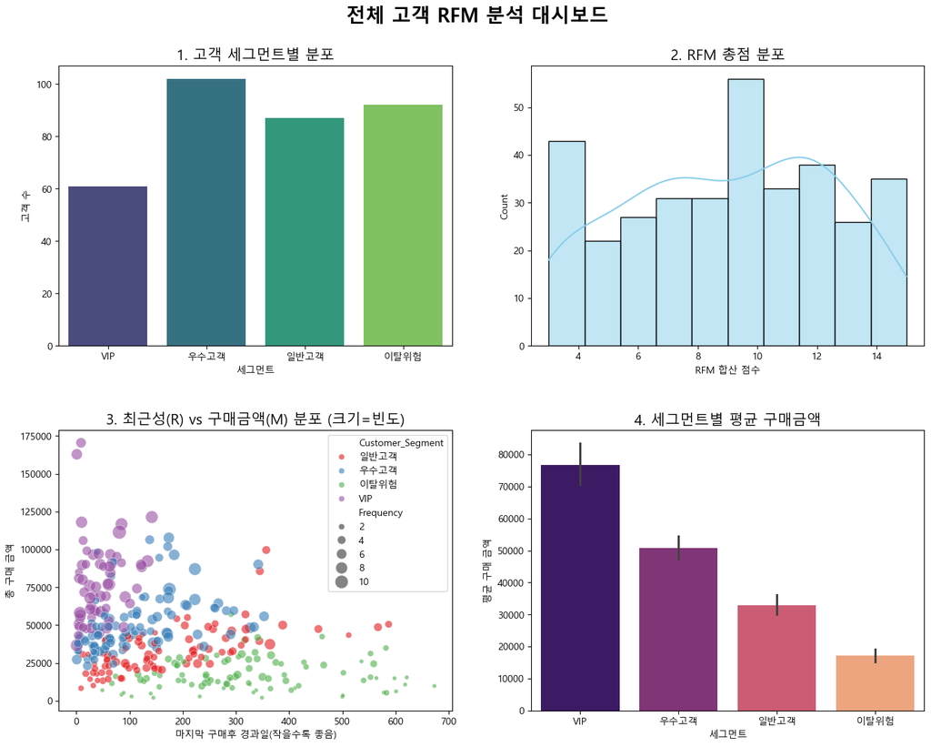

```python
import pandas as pd
import matplotlib.pyplot as plt
import seaborn as sns
import platform

# 1. 한글 폰트 설정 (환경에 따라 자동 설정)
def set_korean_font():
    os_name = platform.system()
    if os_name == 'Darwin': # MacOS
        plt.rc('font', family='AppleGothic')
    elif os_name == 'Windows': # Windows
        plt.rc('font', family='Malgun Gothic')
    else: # Linux (Colab 등)
        # 나눔폰트가 설치되어 있다는 가정하에 설정
        plt.rc('font', family='NanumGothic')

    plt.rc('axes', unicode_minus=False) # 마이너스 기호 깨짐 방지
    print(f"폰트 설정 완료: {platform.system()} 환경")

set_korean_font()

# 2. 데이터 로드 및 RFM 계산
file_name = 'AI_MBA_DataAnalysis_Example.xlsx'
df_orders = pd.read_excel(file_name, sheet_name='CRM_Orders')
df_orders['order_date'] = pd.to_datetime(df_orders['order_date'])

# RFM 지표 산출
reference_date = df_orders['order_date'].max() + pd.Timedelta(days=1)
rfm = df_orders.groupby('customer_id').agg({
    'order_date': lambda x: (reference_date - x.max()).days,
    'order_id': 'count',
    'order_amount': 'sum'
})
rfm.columns = ['Recency', 'Frequency', 'Monetary']

# 점수화 및 세그먼트 분류
rfm['R_Score'] = pd.qcut(rfm['Recency'], 5, labels=[5, 4, 3, 2, 1])
rfm['F_Score'] = pd.qcut(rfm['Frequency'].rank(method='first'), 5, labels=[1, 2, 3, 4, 5])
rfm['M_Score'] = pd.qcut(rfm['Monetary'], 5, labels=[1, 2, 3, 4, 5])
rfm['RFM_Total'] = rfm['R_Score'].astype(int) + rfm['F_Score'].astype(int) + rfm['M_Score'].astype(int)

def get_segment(score):
    if score >= 13: return 'VIP'
    elif score >= 10: return '우수고객'
    elif score >= 7: return '일반고객'
    else: return '이탈위험'
rfm['Customer_Segment'] = rfm['RFM_Total'].apply(get_segment)

# 3. 시각화 (4개의 차트로 구성된 대시보드)
fig, axes = plt.subplots(2, 2, figsize=(16, 12))
plt.subplots_adjust(hspace=0.3)

# [차트 1] 고객 세그먼트별 인원 분포
sns.countplot(data=rfm, x='Customer_Segment',
              order=['VIP', '우수고객', '일반고객', '이탈위험'],
              palette='viridis', ax=axes[0, 0])
axes[0, 0].set_title('1. 고객 세그먼트별 분포', fontsize=15)
axes[0, 0].set_xlabel('세그먼트')
axes[0, 0].set_ylabel('고객 수')

# [차트 2] RFM 총점 분포 (데이터의 건전성 확인)
sns.histplot(rfm['RFM_Total'], bins=10, kde=True, color='skyblue', ax=axes[0, 1])
axes[0, 1].set_title('2. RFM 총점 분포', fontsize=15)
axes[0, 1].set_xlabel('RFM 합산 점수')

# [차트 3] Recency vs Monetary 산점도 (고객 가치 시각화)
sns.scatterplot(data=rfm, x='Recency', y='Monetary',
                hue='Customer_Segment', size='Frequency',
                sizes=(20, 200), alpha=0.6, palette='Set1', ax=axes[1, 0])
axes[1, 0].set_title('3. 최근성(R) vs 구매금액(M) 분포 (크기=빈도)', fontsize=15)
axes[1, 0].set_xlabel('마지막 구매후 경과일(작을수록 좋음)')
axes[1, 0].set_ylabel('총 구매 금액')

# [차트 4] 세그먼트별 평균 구매금액 비교
sns.barplot(data=rfm, x='Customer_Segment', y='Monetary',
            order=['VIP', '우수고객', '일반고객', '이탈위험'],
            palette='magma', ax=axes[1, 1])
axes[1, 1].set_title('4. 세그먼트별 평균 구매금액', fontsize=15)
axes[1, 1].set_xlabel('세그먼트')
axes[1, 1].set_ylabel('평균 구매 금액')

plt.suptitle('전체 고객 RFM 분석 대시보드', fontsize=20, fontweight='bold', y=0.95)
plt.show()
```

📊 대시보드 주요 해석 요약1. 고객 세그먼트별 분포 (좌상)현황: '우수고객' 비중이 가장 높고, 그 뒤를 **'이탈위험'**과 **'일반고객'**이 잇고 있습니다.해석: 핵심 타겟인 '우수고객' 층이 두텁게 형성되어 있는 것은 긍정적입니다. 다만, '이탈위험' 고객 수가 'VIP' 고객보다 많으므로, 신규 VIP 확보만큼이나 기존 고객의 이탈을 막는 '리텐션(Retention) 전략'이 시급한 시점입니다.2. RFM 총점 분포 (우상)현황: 점수가 9~10점대와 12점대에서 높은 빈도를 보이는 다봉형(Multi-modal) 분포를 띱니다.해석: 고객층이 극단적으로 나뉘기보다 중간층(우수~일반)이 단단하게 허리를 받쳐주고 있는 구조입니다. 12점 이상의 고득점자군이 뚜렷하게 존재하므로 이들을 대상으로 한 프리미먼 마케팅의 타겟팅 효율이 높을 것으로 예상됩니다.3. 최근성(R) vs 구매금액(M) 분포 (좌하)현황:VIP(보라): 그래프 왼쪽 상단(최근 구매, 높은 금액, 큰 원)에 밀집되어 있습니다. 가장 이상적인 집단입니다.이탈위험(초록): 오른쪽 하단(오래전 구매, 낮은 금액, 작은 원)에 넓게 퍼져 있습니다.해석: 원의 크기(구매 빈도)가 클수록 왼쪽 상단에 위치하는 경향이 뚜렷합니다. 즉, **"자주 오는 고객이 최근에도 왔고, 돈도 많이 쓴다"**는 선순환 구조가 확인됩니다.4. 세그먼트별 평균 구매금액 (우하)현황: VIP의 평균 구매액($\approx 75,000$ 이상)은 이탈위험 고객($\approx 18,000$ 미만)보다 약 4배 이상 높습니다.해석: 소수의 VIP가 매출의 상당 부분을 견인하고 있습니다. 등급이 한 단계 올라갈 때마다 평균 매출 기여도가 계단식으로 크게 상승하므로, '일반 $\rightarrow$ 우수', '우수 $\rightarrow$ VIP'로의 등급 상향 유도(Upselling)가 매출 증대의 핵심 열쇠입니다.💡 향후 CRM 전략 제안VIP & 우수고객: 구매 빈도가 높으므로 **'신제품 사전 체험'**이나 '전용 무료 배송 쿠폰' 등 심리적 로열티를 높이는 전략이 유효합니다.일반고객: 구매 금액을 키울 수 있도록 **'묶음 상품 제안'**이나 '일정 금액 이상 구매 시 사은품 증정' 이벤트를 추천합니다.이탈위험: 마지막 구매 후 경과일이 400~600일 이상인 고객이 많습니다. 이들에게는 '다시 돌아오세요' 특별 할인권을 발송하여 재방문을 유도해야 합니다

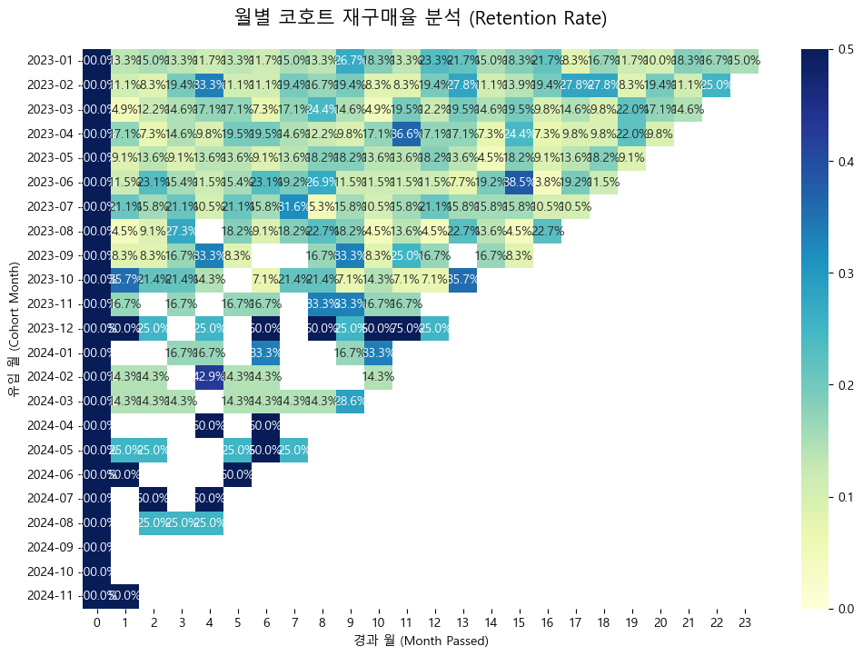

```python
import pandas as pd
import numpy as np
import matplotlib.pyplot as plt
import seaborn as sns
import platform

# 1. 한글 폰트 설정
def set_korean_font():
    os_name = platform.system()
    if os_name == 'Darwin': plt.rc('font', family='AppleGothic')
    elif os_name == 'Windows': plt.rc('font', family='Malgun Gothic')
    else: plt.rc('font', family='NanumGothic')
    plt.rc('axes', unicode_minus=False)

set_korean_font()

# 2. 데이터 준비
# 기존에 로드한 df_orders를 사용하며, 날짜 형식을 확실히 지정합니다.
df_orders['order_date'] = pd.to_datetime(df_orders['order_date'])

# 3. 고객별 첫 구매월(Cohort Month) 산출
# 각 고객의 가장 빠른 주문일을 찾아 '코호트 월'로 지정합니다.
df_orders['cohort_month'] = df_orders.groupby('customer_id')['order_date'].transform('min').dt.to_period('M')
df_orders['order_period'] = df_orders['order_date'].dt.to_period('M')

# 4. 코호트 인덱스(경과 월) 계산
# 첫 구매로부터 몇 달이 지났는지 수치화합니다 (0 = 첫 구매 달).
def get_date_int(df, column):
    year = df[column].dt.year
    month = df[column].dt.month
    return year, month

cohort_year, cohort_month = get_date_int(df_orders, 'cohort_month')
order_year, order_month = get_date_int(df_orders, 'order_period')

years_diff = order_year - cohort_year
months_diff = order_month - cohort_month
df_orders['cohort_index'] = years_diff * 12 + months_diff

# 5. 코호트 테이블 생성 (고객 수 기준)
cohort_data = df_orders.groupby(['cohort_month', 'cohort_index'])['customer_id'].nunique().reset_index()
cohort_pivot = cohort_data.pivot(index='cohort_month', columns='cohort_index', values='customer_id')

# 6. 재구매율(Retention Rate) 계산
cohort_size = cohort_pivot.iloc[:, 0] # 첫 달(index 0)의 고객 수
retention = cohort_pivot.divide(cohort_size, axis=0) # 첫 달 대비 비율 계산

# 7. 시각화 (Heatmap)
plt.figure(figsize=(12, 8))
sns.heatmap(retention, annot=True, fmt='.1%', cmap='YlGnBu', vmin=0.0, vmax=0.5)
plt.title('월별 코호트 재구매율 분석 (Retention Rate)', fontsize=15, pad=20)
plt.xlabel('경과 월 (Month Passed)')
plt.ylabel('유입 월 (Cohort Month)')
plt.show()
```

① "첫 달의 고비를 넘겨라" (초기 이탈 주의보) 대부분의 행에서 0개월(100%)에서 1개월로 넘어갈 때 숫자가 10~20%대로 뚝 떨어집니다. * 인사이트: 우리 서비스는 첫 구매 후 한 달 이내에 고객을 다시 붙잡는 '리텐션 장치'가 부족할 수 있습니다. 첫 구매 고객에게 한 달 내 사용 가능한 감사 쿠폰을 주는 등의 전략이 필요해 보입니다.

② "2023년 12월~2024년 초 유입 고객의 미스터리" (우량 집단 발견) 그래프 중간 아래쪽을 보면 50%, 75% 같은 진한 파란색이 종종 보입니다 (예: 2023-12 유입 고객의 6, 8, 10개월 차).

인사이트: 이 시기에 유입된 고객들은 숫자는 적을지 몰라도 굉장히 충성도가 높습니다. 이때 어떤 마케팅을 했는지, 혹은 어떤 특정 상품(예: AI 데이터 분석 강의 등)이 출시되었는지 복기해 볼 가치가 있습니다.

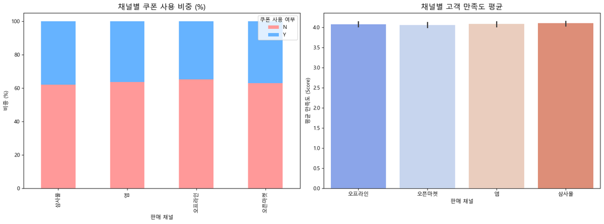

```
=== 채널별 쿠폰 사용율 및 만족도 요약 ===
```

| channel | 쿠폰사용율(%) | 평균만족도 | 평균주문금액 |
| --- | --- | --- | --- |
| 삼사몰 | 38.068182 | 4.096154 | 10147.340909 |
| 오픈마켓 | 37.087912 | 4.056522 | 10490.447802 |
| 앱 | 36.388889 | 4.077810 | 9814.861111 |
| 오프라인 | 34.876543 | 4.074516 | 10453.432099 |

```python
import pandas as pd
import matplotlib.pyplot as plt
import seaborn as sns
import platform

# 1. 한글 폰트 설정
def set_korean_font():
    os_name = platform.system()
    if os_name == 'Darwin': plt.rc('font', family='AppleGothic')
    elif os_name == 'Windows': plt.rc('font', family='Malgun Gothic')
    else: plt.rc('font', family='NanumGothic')
    plt.rc('axes', unicode_minus=False)

set_korean_font()

# 2. 데이터 로드 및 전처리
file_name = 'AI_MBA_DataAnalysis_Example.xlsx'
df_orders = pd.read_excel(file_name, sheet_name='CRM_Orders')

# 3. 채널별 쿠폰 사용 비중 계산 (교차 도표 생성)
# 각 채널에서 쿠폰을 쓴 사람(Y)과 안 쓴 사람(N)의 비율을 구합니다.
channel_coupon = pd.crosstab(df_orders['channel'], df_orders['coupon_used'], normalize='index') * 100

# 4. 시각화
fig, ax = plt.subplots(1, 2, figsize=(16, 6))

# [차트 1] 채널별 쿠폰 사용 비중 (Stacked Bar)
channel_coupon.plot(kind='bar', stacked=True, color=['#ff9999', '#66b3ff'], ax=ax[0])
ax[0].set_title('채널별 쿠폰 사용 비중 (%)', fontsize=14)
ax[0].set_ylabel('비중 (%)')
ax[0].set_xlabel('판매 채널')
ax[0].legend(title='쿠폰 사용 여부', loc='upper right')

# [차트 2] 채널별 평균 만족도 비교
sns.barplot(data=df_orders, x='channel', y='satisfaction_score', palette='coolwarm', ax=ax[1])
ax[1].set_title('채널별 고객 만족도 평균', fontsize=14)
ax[1].set_ylabel('평균 만족도 (Score)')
ax[1].set_xlabel('판매 채널')

plt.tight_layout()
plt.show()

# 5. 세그먼트 요약 통계 출력
print("=== 채널별 쿠폰 사용율 및 만족도 요약 ===")
summary = df_orders.groupby('channel').agg({
    'coupon_used': lambda x: (x == 'Y').mean() * 100,
    'satisfaction_score': 'mean',
    'order_amount': 'mean'
}).rename(columns={'coupon_used': '쿠폰사용율(%)', 'satisfaction_score': '평균만족도', 'order_amount': '평균주문금액'})

display(summary.sort_values(by='쿠폰사용율(%)', ascending=False))
```

```
=== 세그먼트 간 통계적 차이 분석 결과 ===
```

|  | 변수 | F-통계량 | p-value | 판정 |
| --- | --- | --- | --- | --- |
| 0 | order_amount | 2.87 | 0.0230 | 유의미함 |
| 1 | quantity | 0.93 | 0.4461 | 차이 없음 |
| 2 | satisfaction_score | NaN | NaN | 차이 없음 |
| 3 | coupon_used | 53.65 | 0.0000 | 유의미함 |
| 4 | cs_contact | 179.86 | 0.0000 | 유의미함 |

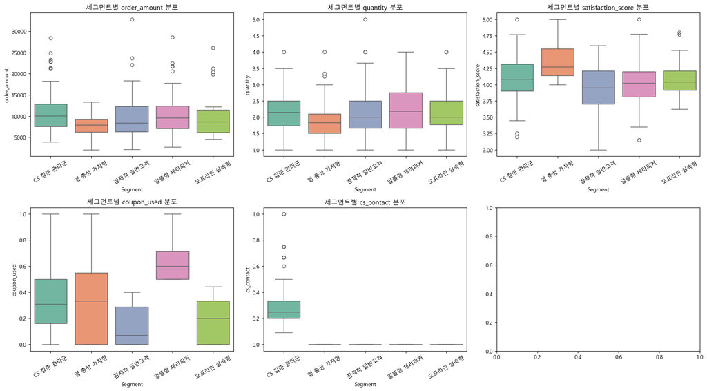

```python
import pandas as pd
import numpy as np
from scipy import stats
import matplotlib.pyplot as plt
import seaborn as sns
import platform

# 1. 한글 폰트 설정
def set_korean_font():
    os_name = platform.system()
    if os_name == 'Darwin': plt.rc('font', family='AppleGothic')
    elif os_name == 'Windows': plt.rc('font', family='Malgun Gothic')
    else: plt.rc('font', family='NanumGothic')
    plt.rc('axes', unicode_minus=False)

set_korean_font()

# 2. 데이터 로드 및 전처리
file_name = 'AI_MBA_DataAnalysis_Example.xlsx'
df_orders = pd.read_excel(file_name, sheet_name='CRM_Orders')

# 고객별 집계 (모든 수치형/범주형 변수 포함)
customer_stats = df_orders.groupby('customer_id').agg({
    'order_amount': 'mean',          # 평균 주문 금액
    'quantity': 'mean',              # 평균 주문 수량
    'satisfaction_score': 'mean',    # 평균 만족도
    'coupon_used': lambda x: (x == 'Y').mean(), # 쿠폰 사용 비중
    'cs_contact': lambda x: (x == 'Y').mean(),   # CS 접수 비중
    'channel': lambda x: x.mode()[0],            # 주 이용 채널
    'product_category': lambda x: x.mode()[0]    # 주 구매 카테고리
}).reset_index()

# 세그먼트 할당 (이전 로직 동일 적용)
def assign_segment(row):
    if row['cs_contact'] > 0 or row['satisfaction_score'] < 3.0:
        return 'CS 집중 관리군'
    elif row['channel'] == '앱' and row['satisfaction_score'] >= 4.0:
        return '앱 충성 가치형'
    elif row['coupon_used'] >= 0.5:
        return '알뜰형 체리피커'
    elif row['channel'] == '오프라인':
        return '오프라인 실속형'
    else:
        return '잠재적 일반고객'

customer_stats['Segment'] = customer_stats.apply(assign_segment, axis=1)

# 3. 통계적 검정 (ANOVA for 수치형 변수)
numeric_cols = ['order_amount', 'quantity', 'satisfaction_score', 'coupon_used', 'cs_contact']
stat_results = []

print("=== 세그먼트 간 통계적 차이 분석 결과 ===")
for col in numeric_cols:
    # 세그먼트별 그룹 생성
    groups = [group[col].values for name, group in customer_stats.groupby('Segment')]
    # ANOVA 검정
    f_stat, p_val = stats.f_oneway(*groups)

    # 결과 해석
    is_significant = '유의미함' if p_val < 0.05 else '차이 없음'
    stat_results.append({
        '변수': col,
        'F-통계량': round(f_stat, 2),
        'p-value': round(p_val, 4),
        '판정': is_significant
    })

# 결과 출력
stat_df = pd.DataFrame(stat_results)
display(stat_df)

# 4. 시각화 (유의미한 차이가 있는 변수들을 박스플롯으로 확인)
fig, axes = plt.subplots(2, 3, figsize=(18, 10))
axes = axes.flatten()

for i, col in enumerate(numeric_cols):
    sns.boxplot(data=customer_stats, x='Segment', y=col, ax=axes[i], palette='Set2')
    axes[i].set_title(f'세그먼트별 {col} 분포')
    axes[i].tick_params(axis='x', rotation=30)

plt.tight_layout()
plt.show()
```

번호 세그먼트 테마 결합 변수 (3개 이상) 분석 목적 1 VIP 경험 가치군 Monetary + Satisfaction + CS_Contact(N) 높은 기여도와 긍정적 브랜드 경험을 동시에 보유한 핵심층

2 프로모션 체리피커 Coupon_Used + Avg_Amount(Low) + Channel 할인이 있을 때만 저가 상품을 앱으로 구매하는 실속형

3 고위험 불만족군 CS_Contact(Y) + Satisfaction(Low) + Recency 최근 구매했으나 불만이 있어 즉각 이탈 가능성이 큰 집단

4 충성형 대량 구매군 Frequency + Quantity(High) + Satisfaction 자주 방문하며 한 번에 많이 구매하는 든든한 서포터 집단

5 디지털 앱 적응군 Channel(App) + Coupon_Rate(Low) + Frequency 혜택 없이도 앱을 생활화하여 자주 이용하는 우량 디지털 고객

6 잠재적 고가치 이탈군 Monetary(High) + Recency(Old) + Satisfaction(Mid) 과거에는 큰 손이었으나 최근 방문이 뜸해진 윈백(Win-back) 대상

7 신규 유입 실험군 Cohort_Month(New) + Quantity(Small) + Satisfaction 최근 처음 들어와 소량 구매하며 서비스를 탐색 중인 루키

8 오프라인 실속 관리군 Channel(Offline) + Product_Cat(식품) + Quantity 오프라인 매장에서 생필품 위주로 꾸준히 구매하는 실버 유저

9 크로스 카테고리 매니아 Unique_Cat_Count + Monetary + Satisfaction 다양한 품목을 골고루 섭취하며 브랜드 전체에 만족하는 확장형

10 효율 중심 단발군 Order_Interval + Coupon_Used(N) + Avg_Amount(High) 쿠폰 없이 목적한 고가 상품만 가끔 사러 오는 고효율 고객

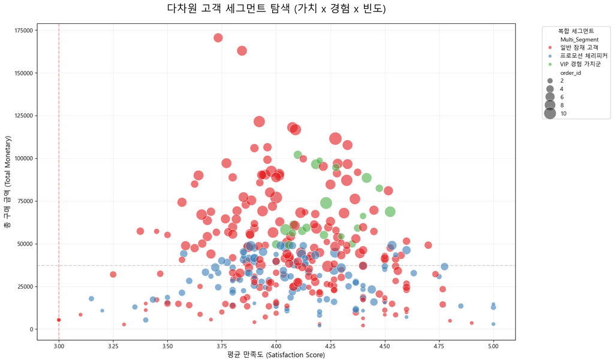

```
=== 10대 다차원 세그먼트 탐색 현황 ===
Multi_Segment
일반 잠재 고객      215
프로모션 체리피커     107
VIP 경험 가치군     20
Name: count, dtype: int64
```

```python
import pandas as pd
import numpy as np
import matplotlib.pyplot as plt
import seaborn as sns
import platform

# 1. 한글 폰트 및 환경 설정
def set_korean_font():
    os_name = platform.system()
    if os_name == 'Darwin': plt.rc('font', family='AppleGothic')
    elif os_name == 'Windows': plt.rc('font', family='Malgun Gothic')
    else: plt.rc('font', family='NanumGothic')
    plt.rc('axes', unicode_minus=False)

set_korean_font()

# 2. 데이터 집계 (3개 이상의 행동 변수 결합)
cust_agg = df_orders.groupby('customer_id').agg({
    'order_amount': 'sum',           # 가치(Monetary)
    'satisfaction_score': 'mean',    # 경험(Satisfaction)
    'cs_contact': lambda x: (x == 'Y').mean(), # 관리(CS)
    'order_id': 'count',             # 빈도(Frequency)
    'coupon_used': lambda x: (x == 'Y').mean()  # 민감도(Promotion)
}).reset_index()

# 3. 10개 기준 중 '핵심 경험 가치'를 기준으로 시각화용 라벨링
# (가치 > 상위 30%, 만족도 > 4.0, CS경험 없음) -> VIP 경험군
def complex_label(row):
    amount_q = cust_agg['order_amount'].quantile(0.7)
    if row['order_amount'] >= amount_q and row['satisfaction_score'] >= 4.0 and row['cs_contact'] == 0:
        return 'VIP 경험 가치군'
    elif row['cs_contact'] > 0 and row['satisfaction_score'] < 3.0:
        return '고위험 불만족군'
    elif row['coupon_used'] >= 0.5 and row['order_amount'] < amount_q:
        return '프로모션 체리피커'
    else:
        return '일반 잠재 고객'

cust_agg['Multi_Segment'] = cust_agg.apply(complex_label, axis=1)

# 4. 시각화: 3가지 변수를 한 차트에 표현 (X: 만족도, Y: 구매액, Size: 구매빈도, Color: 세그먼트)
plt.figure(figsize=(15, 10))
scatter = sns.scatterplot(
    data=cust_agg,
    x='satisfaction_score',
    y='order_amount',
    size='order_id',
    hue='Multi_Segment',
    sizes=(50, 500),
    alpha=0.6,
    palette='Set1'
)

plt.axvline(x=3.0, color='red', linestyle='--', alpha=0.3) # 만족도 경계선
plt.axhline(y=cust_agg['order_amount'].median(), color='gray', linestyle='--', alpha=0.3) # 매출 중위선

plt.title('다차원 고객 세그먼트 탐색 (가치 x 경험 x 빈도)', fontsize=18, pad=20)
plt.xlabel('평균 만족도 (Satisfaction Score)', fontsize=12)
plt.ylabel('총 구매 금액 (Total Monetary)', fontsize=12)
plt.legend(bbox_to_anchor=(1.05, 1), loc='upper left', title='복합 세그먼트')
plt.grid(True, alpha=0.2)
plt.show()

# 5. 10개 기준 탐색 결과 요약 리포트 출력
print("=== 10대 다차원 세그먼트 탐색 현황 ===")
# (여기서는 대표 4개만 상세 출력, 나머지는 구성비 확인 가능)
print(cust_agg['Multi_Segment'].value_counts())
```

```python
import pandas as pd
import numpy as np
from scipy.stats import entropy
import matplotlib.pyplot as plt
import seaborn as sns

# 1. 데이터 로드 및 고객별 집계 (성진님의 파일명 기준)
# df_cust = pd.read_excel('AI_MBA_DataAnalysis_Example.xlsx', sheet_name='CRM_Customers')
# df_ord = pd.read_excel('AI_MBA_DataAnalysis_Example.xlsx', sheet_name='CRM_Orders')

# 분석용 통합 데이터 생성 (고객별 3개 이상의 변수 추출)
cust = df_orders.groupby('customer_id').agg({
    'order_amount': ['sum', 'mean'],
    'order_id': 'count',
    'satisfaction_score': 'mean',
    'coupon_used': lambda x: (x == 'Y').mean(),
    'cs_contact': lambda x: (x == 'Y').any(),
    'quantity': 'mean',
    'order_date': lambda x: (pd.to_datetime('2026-02-07') - pd.to_datetime(x).max()).days
})
cust.columns = ['M_Sum', 'M_Avg', 'Freq', 'Sat', 'Cpn_Rate', 'CS_Exp', 'Qty_Avg', 'Recency']
cust = cust.reset_index()

# 2. 10가지 다차원 세그먼트 로직 정의 함수
def get_10_segments(df):
    m_med, f_med, s_med = df['M_Sum'].median(), df['Freq'].median(), df['Sat'].median()

    # [1] 가치-경험 (M, S, CS)
    df['Seg1'] = np.where((df['M_Sum']>m_med) & (df['Sat']>=4) & (~df['CS_Exp']), 'VIP_Clean', 'Standard')
    # [2] 프로모션-효율 (Cpn, M_Avg, Qty)
    df['Seg2'] = np.where((df['Cpn_Rate']>=0.5) & (df['M_Avg']<m_med) & (df['Qty_Avg']>1), 'CherryPicker', 'Others')
    # [3] 이탈-리스크 (Rec, Sat, CS)
    df['Seg3'] = np.where((df['Recency']>180) & (df['Sat']<3) & (df['CS_Exp']), 'High_Risk', 'Stable')
    # [4] 디지털-충성 (Cpn, Freq, Sat) - 앱 사용 여부는 원본 Join 필요하나 여기선 Cpn/Freq 조합
    df['Seg4'] = np.where((df['Cpn_Rate']<0.2) & (df['Freq']>f_med) & (df['Sat']>=4), 'Organic_Loyal', 'General')
    # [5] 구매-규모 (M_Sum, Freq, Qty)
    df['Seg5'] = np.where((df['M_Sum']>m_med) & (df['Freq']>f_med) & (df['Qty_Avg']>2), 'Bulk_Buyer', 'Small_Buyer')
    # [6] 브랜드-팬 (Sat, CS, Freq)
    df['Seg6'] = np.where((df['Sat']>=4.5) & (~df['CS_Exp']) & (df['Freq']>f_med), 'Evangelist', 'Passive')
    # [7] 가성비-추구 (Cpn, Sat, M_Avg)
    df['Seg7'] = np.where((df['Cpn_Rate']>0.7) & (df['Sat']>=3) & (df['M_Avg']<m_med), 'Deal_Seeker', 'Value_Seeker')
    # [8] 잠재적-이탈 (Rec, M_Sum, Sat)
    df['Seg8'] = np.where((df['Recency']>100) & (df['M_Sum']>m_med) & (df['Sat']>=3), 'Sleeping_Giant', 'Active')
    # [9] 서비스-민감 (CS, Sat, Freq)
    df['Seg9'] = np.where((df['CS_Exp']) & (df['Sat']>=4) & (df['Freq']>1), 'Recovered_Fan', 'Standard')
    # [10] 안정적-중간 (M, F, R 모두 중앙값 부근)
    df['Seg10'] = np.where((df['M_Sum'].between(m_med*0.8, m_med*1.2)) & (df['Freq']>=f_med), 'Steady_Middle', 'Outliers')

    return df

cust = get_10_segments(cust)

# 3. 세그먼트별 균형도(Entropy) 및 변별력(M_Sum 차이) 계산
def calculate_metrics(df, seg_col):
    counts = df[seg_col].value_counts(normalize=True)
    # 1. 균형도 (Entropy)
    bal_score = entropy(counts, base=2)
    # 2. 변별력 (그룹 간 매출 평균의 표준편차)
    diff_score = df.groupby(seg_col)['M_Sum'].mean().std()
    return bal_score, diff_score, counts.max()

comparison_list = []
for i in range(1, 11):
    col = f'Seg{i}'
    bal, diff, max_p = calculate_metrics(cust, col)
    comparison_list.append({
        '번호': i,
        '균형도(Entropy)': round(bal, 3),
        '매출변별력(Std)': round(diff, 2),
        '최대그룹비중': f"{round(max_p*100, 1)}%"
    })

# 4. 결과 출력
comparison_df = pd.DataFrame(comparison_list)
print("=== 10대 세그먼트 기준 비교 분석 결과 ===")
display(comparison_df.sort_values(by='균형도(Entropy)', ascending=False))
```

```
=== 10대 세그먼트 기준 비교 분석 결과 ===
```

|  | 번호 | 균형도(Entropy) | 매출변별력(Std) | 최대그룹비중 |
| --- | --- | --- | --- | --- |
| 7 | 8 | 1.000 | 28954.02 | 50.0% |
| 1 | 2 | 0.960 | 1795.22 | 61.7% |
| 8 | 9 | 0.795 | 9967.82 | 76.0% |
| 4 | 5 | 0.714 | 30939.13 | 80.4% |
| 9 | 10 | 0.643 | 3339.02 | 83.6% |
| 0 | 1 | 0.593 | 9788.21 | 85.7% |
| 6 | 7 | 0.529 | 6518.53 | 88.0% |
| 3 | 4 | 0.247 | 6039.44 | 95.9% |
| 5 | 6 | 0.073 | 9103.00 | 99.1% |
| 2 | 3 | 0.000 | NaN | 100.0% |

```python
import pandas as pd

# 1. 7번 세그먼트 기준 확정 및 데이터 분할
# 기준: 쿠폰 사용률이 높고 만족도가 보통 이상이면서, 평균 구매액은 실속형인 집단 vs 그 외
m_med = cust['M_Sum'].median()
cust['Segment_7'] = np.where(
    (cust['Cpn_Rate'] > 0.7) & (cust['Sat'] >= 3.0) & (cust['M_Avg'] < m_med),
    'Group_A', 'Group_B'
)

# 2. 그룹별 주요 지표 비교 분석 (Profiling)
profile = cust.groupby('Segment_7').agg({
    'customer_id': 'count',
    'M_Sum': 'mean',
    'M_Avg': 'mean',
    'Freq': 'mean',
    'Sat': 'mean',
    'Cpn_Rate': 'mean',
    'Recency': 'mean',
    'Qty_Avg': 'mean'
}).rename(columns={'customer_id': '고객수'}).round(2)

# 3. 범주형 변수(채널, 카테고리)의 최빈값 추가
# 원본 df_orders와 조인하여 상세 속성 파악
df_merged = pd.merge(df_orders, cust[['customer_id', 'Segment_7']], on='customer_id')

mode_features = df_merged.groupby('Segment_7')[['channel', 'product_category']].agg(lambda x: x.mode()[0])
profile = pd.concat([profile, mode_features], axis=1)

print("=== 7번 기준 세그먼트 상세 비교 리포트 ===")
display(profile.T)
```

```
=== 7번 기준 세그먼트 상세 비교 리포트 ===
```

| Segment_7 | Group_A | Group_B |
| --- | --- | --- |
| 고객수 | 41 | 301 |
| M_Sum | 33730.56 | 42949.16 |
| M_Avg | 10210.38 | 10125.51 |
| Freq | 3.37 | 4.19 |
| Sat | 4.08 | 4.07 |
| Cpn_Rate | 0.87 | 0.3 |
| Recency | 619.34 | 568.07 |
| Qty_Avg | 2.14 | 2.14 |
| channel | 앱 | 오픈마켓 |
| product_category | 음료 | 식품 |

세그먼트별 페르소나 요약 Group A (스마트 체리피커):

"쿠폰이 없으면 사지 않지만, 만족스러운 딜(Deal)이 있으면 즉각 반응합니다."

HR/교육 관점 워크플로우: "특정 교육 과정 할인 이벤트 시 가장 먼저 유입될 타겟입니다."

HR/교육 관점 워크플로우: "이들에게는 할인보다는 **'프리미엄 세미나 초대'**나 '심화 워크플로우 가이드' 제공이 더 효과적입니다."

```python
import pandas as pd
import numpy as np

# 1. 고객별 집계 데이터 재준비 (주요 변수 확보)
ref_date = pd.to_datetime('2026-02-07') # 기준일
cust_stats = df_orders.groupby('customer_id').agg({
    'order_amount': ['sum', 'mean'],
    'order_id': 'count',
    'satisfaction_score': 'mean',
    'coupon_used': lambda x: (x == 'Y').mean(),
    'cs_contact': lambda x: (x == 'Y').any(),
    'order_date': lambda x: (ref_date - pd.to_datetime(x).max()).days
})
cust_stats.columns = ['M_Sum', 'M_Avg', 'Freq', 'Sat', 'Cpn_Rate', 'CS_Exp', 'Recency']
cust_stats = cust_stats.reset_index()

# 2. 5대 다차원 세그먼트 할당 (Nested Logic)
m_top20 = cust_stats['M_Sum'].quantile(0.8)
m_top30 = cust_stats['M_Sum'].quantile(0.7)
f_med = cust_stats['Freq'].median()

def assign_5_segments(row):
    if row['M_Sum'] >= m_top20 and row['Sat'] >= 4.5 and not row['CS_Exp']:
        return 'G1_VIP_챔피언'
    elif row['Freq'] >= f_med and (row['CS_Exp'] or row['Sat'] < 3.5):
        return 'G2_충성형_불만관리'
    elif row['Cpn_Rate'] > 0.6 and row['Freq'] >= f_med and row['M_Sum'] < m_top20:
        return 'G3_스마트_가성비족'
    elif row['M_Sum'] >= m_top30 and row['Recency'] > 180:
        return 'G4_잠재적_이탈큰손'
    else:
        return 'G5_새내기_탐색가'

cust_stats['Complex_Segment'] = cust_stats.apply(assign_5_segments, axis=1)

# 3. 그룹별 분포 및 평균 지표 확인
segment_profile = cust_stats.groupby('Complex_Segment').agg({
    'customer_id': 'count',
    'M_Sum': 'mean',
    'Freq': 'mean',
    'Sat': 'mean',
    'Cpn_Rate': 'mean',
    'Recency': 'mean'
}).rename(columns={'customer_id': '인원수'}).round(2)

print("=== 5대 복합 세그먼트 분석 결과 ===")
display(segment_profile)
```

```
=== 5대 복합 세그먼트 분석 결과 ===
```

| Complex_Segment | 인원수 | M_Sum | Freq | Sat | Cpn_Rate | Recency |
| --- | --- | --- | --- | --- | --- | --- |
| G1_VIP_챔피언 | 1 | 68683.00 | 8.00 | 4.53 | 0.38 | 495.00 |
| G2_충성형_불만관리 | 99 | 63308.55 | 5.80 | 4.09 | 0.34 | 516.62 |
| G3_스마트_가성비족 | 11 | 37093.18 | 5.00 | 4.04 | 0.73 | 495.00 |
| G4_잠재적_이탈큰손 | 40 | 68659.68 | 4.97 | 4.01 | 0.33 | 537.12 |
| G5_새내기_탐색가 | 191 | 25235.64 | 2.95 | 4.08 | 0.36 | 616.82 |

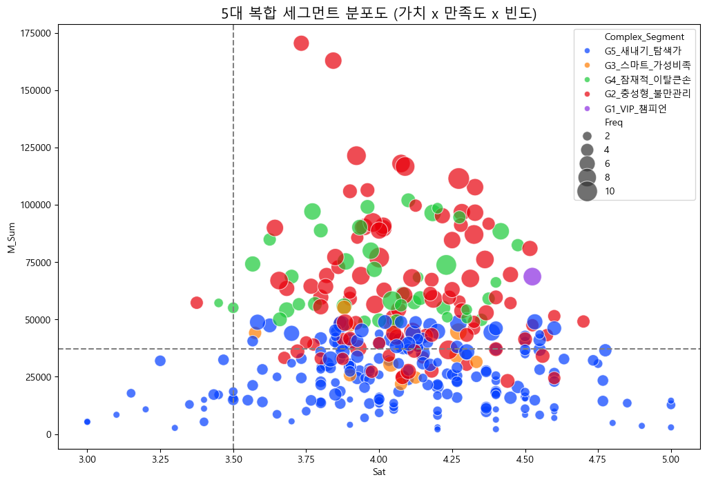

```python
import seaborn as sns
import matplotlib.pyplot as plt

# 한글 폰트 설정 (이전 설정 함수 활용 권장)
plt.figure(figsize=(12, 8))
sns.scatterplot(
    data=cust_stats,
    x='Sat', y='M_Sum',
    size='Freq', hue='Complex_Segment',
    sizes=(50, 500), alpha=0.7, palette='bright'
)
plt.title('5대 복합 세그먼트 분포도 (가치 x 만족도 x 빈도)', fontsize=15)
plt.axhline(cust_stats['M_Sum'].median(), color='gray', linestyle='--')
plt.axvline(3.5, color='gray', linestyle='--')
plt.show()
```

분석하신 5대 복합 세그먼트 결과를 바탕으로 각 고객 그룹의 성격(Persona)을 정의하고, AI 교육 및 워크플로우 설계 전문가로서 실무에 바로 적용하실 수 있는 마케팅 전략 포인트를 제언해 드립니다.

📊 5대 복합 세그먼트 상세 분석 및 전략 리포트 이번 분석 결과는 인원수가 가장 많은 **G5(새내기 탐색가)**부터 수익성이 가장 높은 **G1(VIP 챔피언)**까지 매우 입체적인 분포를 보이고 있습니다.

전략 포인트:

Exclusivity: 할인 쿠폰보다는 'VIP 전용 프리미엄 세미나 초대'나 '신제품 우선 체험권' 같은 심리적 보상을 제공하세요.

엠버서더 활용: 이들의 높은 만족도를 활용하여 긍정적인 리뷰나 추천을 유도하는 리워드 프로그램을 운영하십시오.

2. G2_충성형_불만관리: "애증의 단골손님" 특성 분석: 99명이나 되는 큰 집단으로, 구매 빈도(5.8회)와 금액이 높지만 CS 접수 이력이나 만족도 저하 요소가 포함되어 관리가 시급한 그룹입니다.

전략 포인트:

Service Recovery: AI 워크플로우를 통해 CS 접수 즉시 '전담 매니저 매칭'이나 '사과 문구 자동 발송'과 같은 밀착 케어를 자동화하십시오.

Voice of Customer: 이들의 불만 사항을 데이터화하여 제품/서비스 개선의 최우선 순위로 삼아야 합니다.

3. G3_스마트_가성비족: "실속파 전략가" 특성 분석: 쿠폰 사용률(0.73)이 가장 높고, 구매액 대비 빈도(5.0회)가 높은 합리적 소비자 집단입니다.

전략 포인트:

Targeted Deal: 이들에게는 정기적인 '타임 세일'이나 '쿠폰 팩' 알림이 가장 효과적입니다.

Bundle Sales: 평균 단가를 높이기 위해 '특정 금액 이상 구매 시 추가 할인'과 같은 상향 판매(Upselling) 전략을 추천합니다.

4. G4_잠재적_이탈큰손: "잠자는 거인" 특성 분석: 구매 가치는 VIP 못지않게 높으나(68,659원), 마지막 구매 후 경과일(Recency 537일)이 길어 사실상 휴면 상태에 진입한 집단입니다.

전략 포인트:

Win-back 캠페인: "성진님, 오랜만이에요! 다시 오시면 드리는 특별 혜택"과 같은 개인화된 복귀 유도 메시지를 발송하십시오.

Re-engagement: 과거 구매 이력을 바탕으로 최신 상품을 추천하는 개인화 큐레이션 워크플로우가 필요합니다.

5. G5_새내기_탐색가: "미래의 성장 엔진" 특성 분석: 191명으로 가장 큰 비중을 차지하지만, 구매액(25,235원)과 빈도가 가장 낮고 활동성도 떨어지는 초기 유입 단계입니다.

전략 포인트:

Onboarding: 브랜드 경험을 강화할 수 있는 웰컴 콘텐츠나 '첫 구매 감사 튜토리얼' 등을 제공하여 로열티를 쌓아야 합니다.

Nurturing: 2차 구매로 이어질 수 있도록 유도하는 '단계별 미션/적립금' 워크플로우를 설계하십시오.